# Report

Eli Clapper

23/03/2022

# Intro

Report on the results

### Marginal Descriptives

|  | allsig | gpbf_ic | gpbf_iu | prodbf_ic | prodbf_iu | tbf_ic | tbf_iu |
| --- | --- | --- | --- | --- | --- | --- | --- |
| 25 % | 0 | 0.90009 | 0.92727 | 0.84482 | 0.80715 | 0.76268 | 0.80715 |
| 50 % | 0 | 1.04341 | 1.00647 | 1.05196 | 1.00647 | 1.01309 | 1.00647 |
| 75 % | 0 | 1.37992 | 1.12118 | 2.20912 | 1.31923 | 1.49705 | 1.31923 |
| 90 % | 0 | 1.63447 | 1.22219 | 9.91307 | 2.47179 | 2.60621 | 2.47179 |
| 95 % | 0 | 1.85824 | 1.28825 | 65.20716 | 5.31293 | 5.3363 | 5.31293 |
| mad | 0 | 0.25426 | 0.1304 | 0.6613 | 0.33552 | 0.49902 | 0.33552 |
| sum&gt;3 | 1 | 0 | 0 | 16 | 5 | 6 | 5 |
| max | 10 | 2.17088 | 1.36926 | 2167.10864 | 20.17573 | 20.56114 | 20.17573 |
| min | 0 | 0.72622 | 0.83503 | 0.047 | 0.16809 | 0.16795 | 0.16809 |

Optimally, the algorithms should have $\frac{72}{2} = 36$ conditions where the median BF > 3. The marginal median for all algorithms is $\approx 1.0$, however. Even at the $90^{th}$ percentile only the `prodbf_ic` algorithm has its median BF > 3. The Median Absolute Deviations are not too severe, providing evidence for somewhat reliable estimates. `Prodbf_ic` does have a notably higher mad, which is likely due to its large valued outliers. The finding that the algorithms are rather conservative is further supported by the number of times the median BF does exceed 3. Both `gpbf` algorithms count 0 conditions where median BF > 3, while for `allsig` this number is 1. For the `prodbf_iu` and `tbf` algorithms 5 or 6 times is counted and only the `prodbf_ic` seems to have a more notable number of times the median BF > 3, namely 16. Another observation is that the informative BFs against the unconstrained hypotheses seem to be a bit more conservative than their complement hypotheses counterparts. Finally, it the columns for `prodbf_iu` and `tbf_iu` are exactly equal. Lets check that out.

Let us check it out

```r
all.equal(dat$tbf_iu, dat$prodbf_iu)
```

```
## [1] TRUE
```

```r
cor(dat$tbf_iu, dat$prodbf_iu)
```

```
## [1] 1
```

`tbf_iu` and `prodbf_iu` are indeed perfectly correlated and all values in both columns are equal. Upon further inspection it does not seem to be a simulation error. It seems as if `tbf_iu` and `prodbf_iu` do the exact same thing. It would mean that the product of the unconstrained Bayes Factors is the same as the unconstrained Bayes Factor under the condition that the hypothesis holds for all $k$ groups.

#### Descriptives for es > .1

With this in the back of our mind, let us continue. We can filter the tbf_iu out of the data. Now we subset for when true BF > 3 and describe the distribution for those conditional medians.

|  | allsig | gpbf_ic | gpbf_iu | prodbf_ic | prodbf_iu | tbf_ic |
| --- | --- | --- | --- | --- | --- | --- |
| 25 % | 0 | 1.16448 | 1.05901 | 1.40144 | 1.1371 | 1.172 |
| 50 % | 0 | 1.38547 | 1.1236 | 2.24736 | 1.33591 | 1.50892 |
| 75 % | 0 | 1.59237 | 1.21446 | 6.61487 | 1.9243 | 2.24311 |
| 90 % | 0 | 1.85909 | 1.28955 | 67.86299 | 5.40723 | 5.43151 |
| 95 % | 0 | 2.15738 | 1.35284 | 216.68788 | 7.77978 | 7.83572 |
| mad | 0 | 0.33424 | 0.12396 | 1.58175 | 0.3851 | 0.53973 |
| sum&gt;3 | 1 | 0 | 0 | 16 | 5 | 6 |
| max | 10 | 2.17088 | 1.36926 | 2167.10864 | 20.17573 | 20.56114 |
| min | 0 | 1.05804 | 0.96736 | 1.06185 | 0.7176 | 0.71741 |

```r
all(es_gt_hyp_val['sum>3',] == marginal_descs['sum>3',])
```

[output not shown]

#### Descriptives for es < .1

|  | allsig | gpbf_ic | gpbf_iu | prodbf_ic | prodbf_iu | tbf_ic |
| --- | --- | --- | --- | --- | --- | --- |
| 25 % | 0 | 0.85265 | 0.89248 | 0.48182 | 0.56067 | 0.53602 |
| 50 % | 0 | 0.8966 | 0.92594 | 0.84038 | 0.81732 | 0.76549 |
| 75 % | 0 | 0.99575 | 0.9712 | 0.98554 | 0.93404 | 0.88971 |
| 90 % | 0 | 1.00328 | 0.98937 | 1.02258 | 0.97891 | 0.9693 |
| 95 % | 0 | 1.01331 | 1.00384 | 1.02904 | 1.00384 | 1.00776 |
| mad | 0 | 0.12129 | 0.06275 | 0.23776 | 0.19637 | 0.22145 |
| sum&gt;3 | 0 | 0 | 0 | 0 | 0 | 0 |
| max | 0 | 1.02879 | 1.01419 | 1.04208 | 1.01419 | 1.02879 |
| min | 0 | 0.72622 | 0.83503 | 0.047 | 0.16809 | 0.16795 |

Further supporting the idea of conservative algorithms is the finding is that the maximum median BFs in the cases where es = hyp_val all are $\approx 1$ and all $75^{th}$ percentiles are slightly below one. The algorithms seem to favour the hypotheses that are not in the hypothesized direction, although very moderately. The previously noticed effect of the unconstrained vs the complement algorithms is not immediately visible.

#### correlation metrics between algorithms

Also looking at the correlation between the algorithms, first for the dt with median BFs and afterwards for non-aggregated dt.

|  | allsig | gpbf_ic | gpbf_iu | prodbf_ic | prodbf_iu | tbf_ic |
| --- | --- | --- | --- | --- | --- | --- |
| allsig | 1 | 0.33786 | 0.28978 | -0.0185 | -0.01255 | 0.01907 |
| gpbf_ic | 0.33786 | 1 | 0.98014 | 0.397 | 0.57414 | 0.61699 |
| gpbf_iu | 0.28978 | 0.98014 | 1 | 0.33358 | 0.52327 | 0.56525 |
| prodbf_ic | -0.0185 | 0.397 | 0.33358 | 1 | 0.9064 | 0.9039 |
| prodbf_iu | -0.01255 | 0.57414 | 0.52327 | 0.9064 | 1 | 0.99821 |
| tbf_ic | 0.01907 | 0.61699 | 0.56525 | 0.9039 | 0.99821 | 1 |

A first observation is that `allsig` is only correlated moderately with the `gpbf` algorithms and not at all with the others. Note that this correlation table consists of 72 values per algorithm. The other general trend is that the `gpbf` algorithms have the lowest correlation with `prodbf_ic` and `allsig` and the highest with each other. Finally, the `prodbf` algorithms correlate highly with `tbf` and fairly high with `gpbf`, but less with each other. The `tbf` algorithms do correlate highly together.

For the entire dt

|  | allsig | gpbf_ic | gpbf_iu | prodbf_ic | prodbf_iu | tbf_ic |
| --- | --- | --- | --- | --- | --- | --- |
| allsig | 1 | 0.57148 | 0.45643 | 0.00358 | 0.01616 | 0.1102 |
| gpbf_ic | 0.57148 | 1 | 0.85854 | 0.06827 | 0.33653 | 0.46588 |
| gpbf_iu | 0.45643 | 0.85854 | 1 | 0.06354 | 0.39949 | 0.48407 |
| prodbf_ic | 0.00358 | 0.06827 | 0.06354 | 1 | 0.30998 | 0.30849 |
| prodbf_iu | 0.01616 | 0.33653 | 0.39949 | 0.30998 | 1 | 0.98859 |
| tbf_ic | 0.1102 | 0.46588 | 0.48407 | 0.30849 | 0.98859 | 1 |

We see roughly the same trends. The only real difference seems that all correlations with `prodbf_ic` have lowered quite a bit. This is likely due to the algorithm being able to calculate very large estimates, while the other algorithms are more reserved.

### inspecting conditions when median prodbf_ic > 3

Finally, before going to the non-aggregated `data.table`, I inspect the conditions where median prod_bf > 3. That filetered dt is then ordered by $k$ and $prodbc$_ic values.

|  | es | errorsd | n | k | hyp_val | allsig | gpbf_ic | gpbf_iu | prodbf_ic | prodbf_iu | tbf_ic |
| --- | --- | --- | --- | --- | --- | --- | --- | --- | --- | --- | --- |
| 1 | 0.2 | 0 | 500 | 10 | 0.1 | 0 | 2.156 | 1.35 | 2167.109 | 20.176 | 20.561 |
| 2 | 0.2 | 0 | 200 | 10 | 0.1 | 0 | 1.851 | 1.274 | 470.988 | 11.26 | 11.374 |
| 3 | 0.2 | 0 | 80 | 10 | 0.1 | 0 | 1.629 | 1.203 | 131.921 | 6.35 | 6.384 |
| 4 | 0.2 | 0.5 | 500 | 10 | 0.1 | 0 | 1.576 | 1.208 | 94.421 | 6.62 | 6.656 |
| 5 | 0.2 | 0.5 | 200 | 10 | 0.1 | 0 | 1.451 | 1.161 | 41.305 | 4.464 | 4.479 |
| 6 | 0.2 | 0 | 20 | 10 | 0.1 | 0 | 1.42 | 1.101 | 33.397 | 2.618 | 2.622 |
| 7 | 0.2 | 0.5 | 80 | 10 | 0.1 | 0 | 1.327 | 1.104 | 16.874 | 2.692 | 2.696 |
| 8 | 0.2 | 0.5 | 20 | 10 | 0.1 | 0 | 1.233 | 1.038 | 8.124 | 1.453 | 1.454 |
| 9 | 0.2 | 0.81 | 500 | 10 | 0.1 | 0 | 1.169 | 1.065 | 4.763 | 1.872 | 1.874 |
| 10 | 0.2 | 0.81 | 200 | 10 | 0.1 | 0 | 1.126 | 1.04 | 3.289 | 1.478 | 1.479 |

[output cut: 6 more lines]

The other condition that seems to have some importance is $errorsd$, where most algorithms found an effect when $errorsd \neq 0.81$ and preferably when $errorsd = 0$.

### Confusion matrix metrics

Marginal statistics

|  | correct | Sensitivity | Specificity | FPR | FNR | Pos_lr | Neg_lr |
| --- | --- | --- | --- | --- | --- | --- | --- |
| allsig | 0.54065 | 0.09339 | 0.98792 | 0.01208 | 0.90661 | 7.72874 | 0.9177 |
| gpbf_ic | 0.51239 | 0.03306 | 0.99172 | 0.00828 | 0.96694 | 3.99329 | 0.97502 |
| gpbf_iu | 0.5 | 0 | 1 | 0 | 1 | 0 | 1 |
| prodbf_ic | 0.68414 | 0.44464 | 0.92364 | 0.07636 | 0.55536 | 5.82284 | 0.60128 |
| prodbf_iu | 0.58874 | 0.18353 | 0.99394 | 0.00606 | 0.81647 | 30.30734 | 0.82145 |
| tbf_ic | 0.61518 | 0.24639 | 0.98397 | 0.01603 | 0.75361 | 15.37262 | 0.76589 |
| mean | 0.57352 | 0.16683 | 0.9802 | 0.0198 | 0.83317 | 10.53747 | 0.84689 |

Secondly, all measures also suggest somewhat conservative algorithms, with a mild exception for `prodbf_ic.` The mean sensitivity of the algorithms is 0.17, meaning that on average, out of all cases where BF > 3, only 17% is identified correctly. Interestingly, the `gpbf` algorithms are especially conservative with an almost perfect specificity, but no ability to detect an effect. The `tbf` algorithms and `prodbf_iu` do slightly better in this regard. An obvious outlier is the `prodbf_ic` algorithm with 44% correctly identified when BF > 3.

Where the algorithms make up is in the specificity, with a mean specificty of 0.98. This implies that out of all cases where BF < 3, 98% is identified correctly on average. The prodbf_ic performs only slightly worse than the other algorithms, although the differences are not too severe. The measure does not say much however in combination with the low sensitivity. If all cases are evaluated as having no effect anyway, it is no surprise or feat that the specificity is (close to) perfect. For a clearer picture, we look at the LR+ and LR-.

Looking at the LR+, `prodbf_iu` has the best performance with 30.3, followed by `tbf_ic` with 15.3. It means that the `prodbf_iu`, out all its accredited effects, does best to separate it from actual no effects. The finding that this value is lower for `prodbf_ic` means that it has a higher likelihood of finding an effect when there is none.

The LR- corrects for the the finding that some algorithms’ conservatism. For example, `gpbf_iu` has a value of 1, which means that out of all the tests it determined that there was no effect, 100% of the times it was wrong when in reality there was an effect. `prodbf_ic` actually does best in this regard. Out of all the tests it determined that there was no effect, 60% it was wrong when there in reality was an effect.

A first conclusion would be that the `prodbf_ic` is the algorithm of choice. It is the only algorithm that has a somewhat higher ability to detect an effect when there is one, while still performing well when there is no effect. It does have a somewhat higher probability of finding an effect when there in reality is none which could be a valid concern. When the chance of a Type I error needs to be reduced as much as possible, it would be wiser to choose `prodbf_iu` or `tbf_ic` which have less ability to detect an effect, but are also less likely to call an effect when there in reality is none.

### Plots per condition

First for $errorsd$

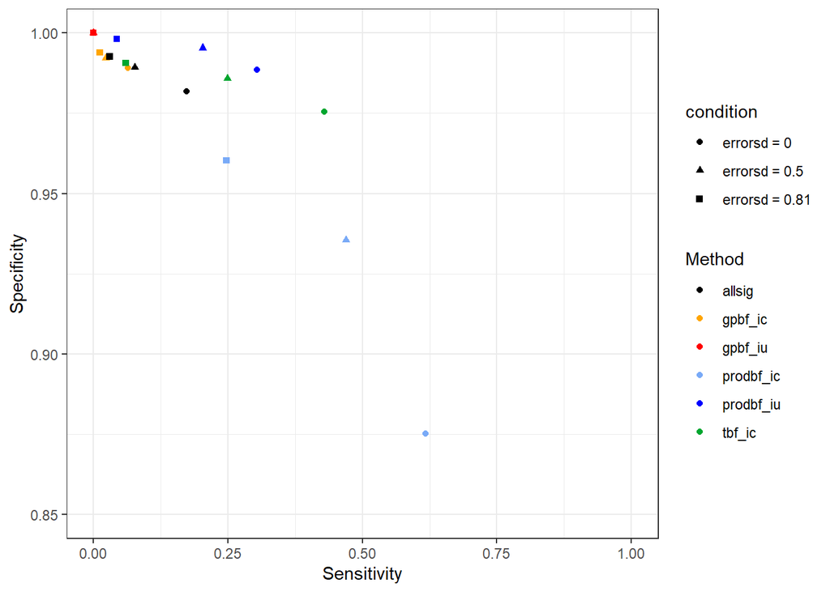

Then for $n$

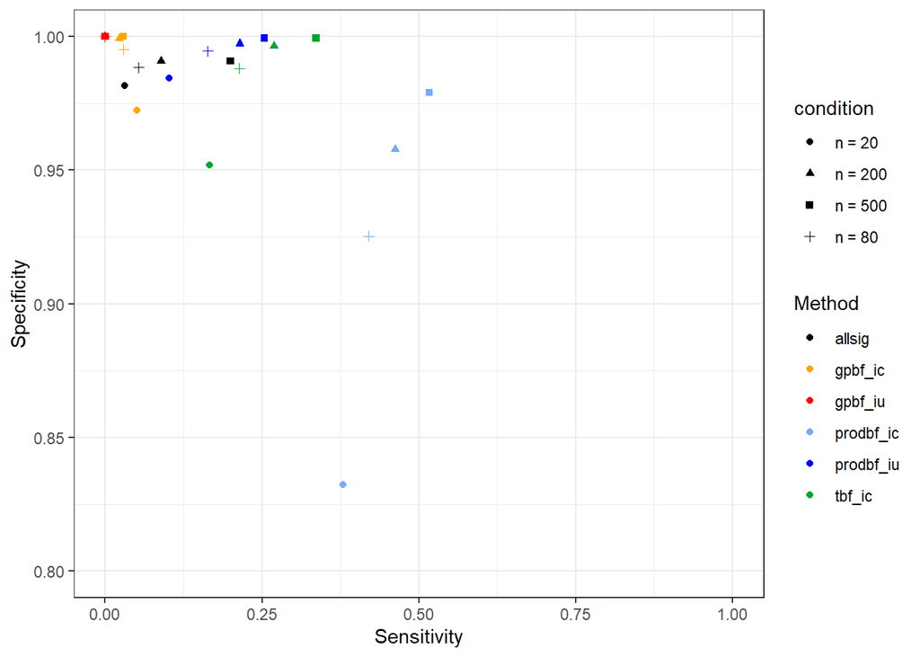

Finally for $k$

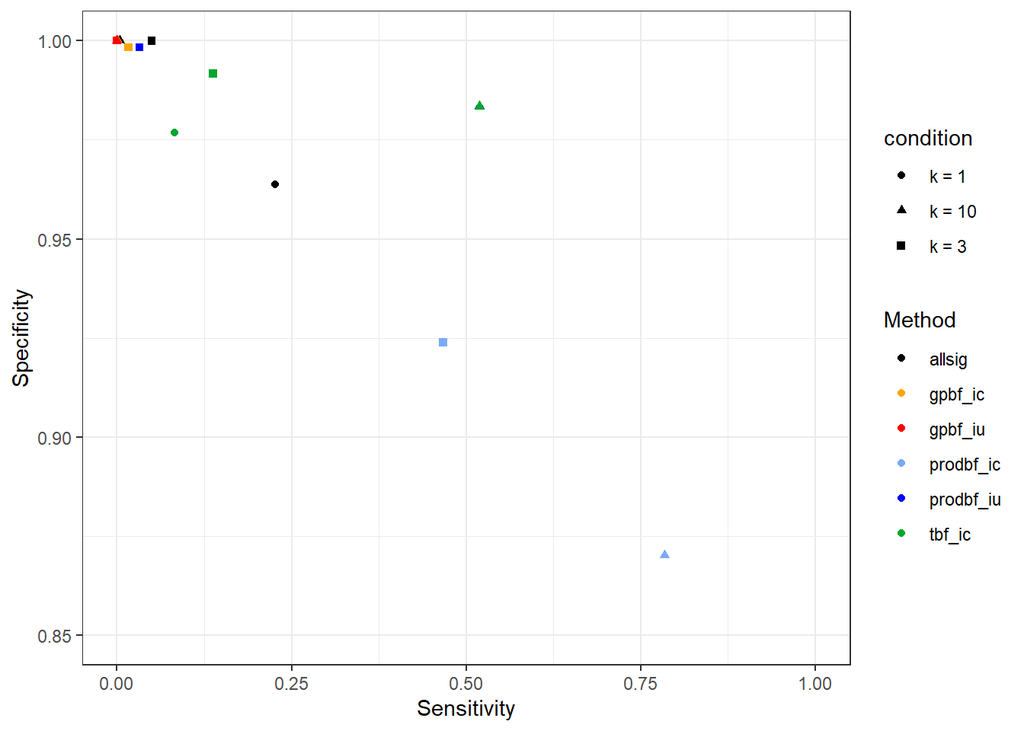